# Определение возраста покупателей

Описание проекта

Сетевой супермаркет «Хлеб-Соль» внедряет систему компьютерного зрения для обработки фотографий покупателей.

Фотофиксация в прикассовой зоне поможет определять возраст клиентов, чтобы:

- Анализировать покупки и предлагать товары, которые могут заинтересовать покупателей этой возрастной группы;
- Контролировать добросовестность кассиров при продаже алкоголя.

Постройте модель, которая по фотографии определит приблизительный возраст человека. В вашем распоряжении набор фотографий людей с указанием возраста.

## Исследовательский анализ данных

```python
import matplotlib.pyplot as plt
import numpy as np
import pandas as pd

from tensorflow.keras.preprocessing.image import ImageDataGenerator
from tensorflow.keras.layers import Dense, GlobalAveragePooling2D
from tensorflow.keras.models import Sequential
from tensorflow.keras.optimizers import Adam
from tensorflow.keras.applications.resnet import ResNet50
```

```python
# проверим сначала таблицу со значениями возраста

labels = pd.read_csv('/datasets/faces/labels.csv')
```

```python
def total_info(data):

    print('Общая информация')
    print()
    print(data.info())
    print()
    print('Случайные 5 строк датасета')
    print(data.sample(5))
    print()
    print('Число пропусков', data.isna().sum())
    print()
    print('Число дубликатов', data.duplicated().sum())
    print()
    print('Описание данных', data.describe())
```

```python
total_info(labels)
```

```
Общая информация

<class 'pandas.core.frame.DataFrame'>
RangeIndex: 7591 entries, 0 to 7590
Data columns (total 2 columns):
 #   Column     Non-Null Count  Dtype
---  ------     --------------  -----
 0   file_name  7591 non-null   object
 1   real_age   7591 non-null   int64
dtypes: int64(1), object(1)
memory usage: 118.7+ KB
None

Случайные 5 строк датасета
       file_name  real_age
6566  006570.jpg        13
3264  003264.jpg        51
1193  001193.jpg        71
5637  005637.jpg        51
5789  005789.jpg        62

Число пропусков file_name    0
real_age     0
dtype: int64

Число дубликатов 0

Описание данных           real_age
count  7591.000000
mean     31.201159
std      17.145060
min       1.000000
25%      20.000000
50%      29.000000
75%      41.000000
max     100.000000
```

```python
# Построим график распределения возраста в выборке

ages  =  labels['real_age'].value_counts()

ages = ages.sort_index()
```

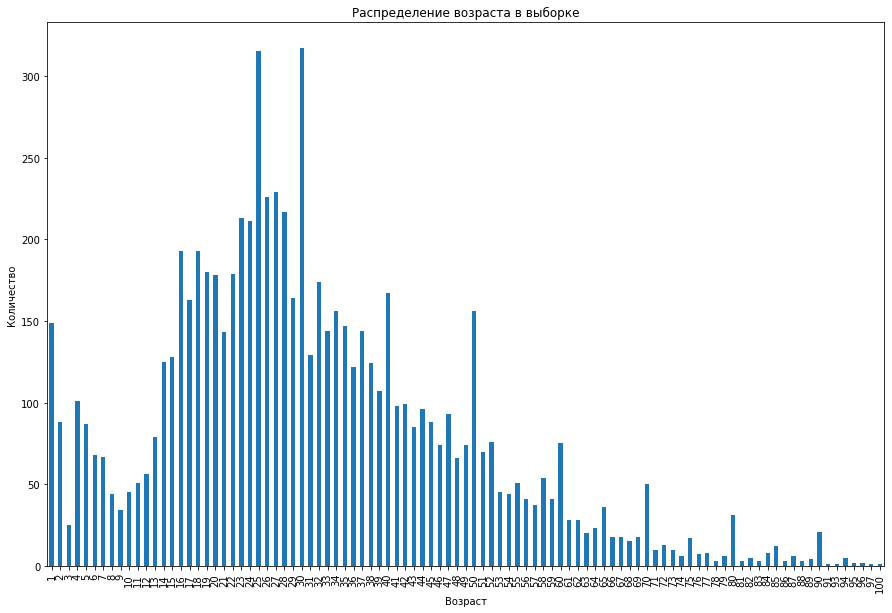

```python
ages.plot(kind = 'bar', figsize=(15, 10))

plt.xlabel('Возраст')
plt.ylabel('Количество')
plt.title('Распределение возраста в выборке')

plt.show()
```

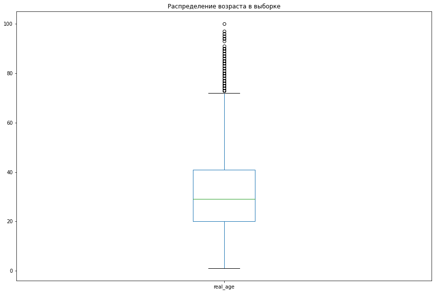

```python
labels['real_age'].plot(kind = 'box', figsize=(15, 10))
plt.title('Распределение возраста в выборке')

plt.show()
```

```python
train_datagen = ImageDataGenerator(rescale=1./255)

train_gen_flow = train_datagen.flow_from_dataframe(
        dataframe=labels,
        directory='/datasets/faces/final_files/',
        x_col='file_name',
        y_col='real_age',
        target_size=(224, 224),
        batch_size=32,
        class_mode='raw',
        seed=12345)
```

```
Found 7591 validated image filenames.
```

```python
features, target = next(train_gen_flow)
```

[figure not shown]

```python
# Напечатаем на экране 15 фотографий

fig = plt.figure(figsize=(10,10))

for i in range(15):
    fig.add_subplot(5, 3, i+1)
    plt.imshow(features[i])

    plt.xticks([])
    plt.yticks([])
    plt.tight_layout()
    plt.title(target[i])
```

Выводы:

- Дан датасет на 7591 изображений с размеченным возрастом людей разных рас
- Возраст в основном в диапазоне 20-41 года
- Часть изображений чб, часть цветные
- Есть фото, где сложно оценить возраст из-за того, что пользователь не смотрит в камеру, его лицо закрыто очками и тд.
- Есть фотографии с ротацией изображений и сильной цветокоррекцией
- С учетом небольшого числа данных и их разнообразия, обучение может быть трудным

## Обучение модели

Перенесите сюда код обучения модели и её результат вывода на экран.

(Код в этом разделе запускается в отдельном GPU-тренажёре, поэтому оформлен не как ячейка с кодом, а как код в текстовой ячейке)

Train for 356 steps, validate for 119 steps

Epoch 1/10

356/356 - 51s - loss: 205.1009 - mae: 10.4135 - val_loss: 603.1538 - val_mae: 19.4968 Epoch 2/10

356/356 - 42s - loss: 83.3494 - mae: 6.9477 - val_loss: 211.9156 - val_mae: 11.1488 Epoch 3/10

356/356 - 42s - loss: 59.4345 - mae: 5.8750 - val_loss: 111.6796 - val_mae: 8.1916 Epoch 4/10

356/356 - 42s - loss: 45.0066 - mae: 5.1497 - val_loss: 71.2088 - val_mae: 6.4928 Epoch 5/10

356/356 - 42s - loss: 33.3189 - mae: 4.4171 - val_loss: 72.6588 - val_mae: 6.4462 Epoch 6/10

356/356 - 43s - loss: 26.8146 - mae: 3.9514 - val_loss: 71.4446 - val_mae: 6.5343 Epoch 7/10

356/356 - 41s - loss: 22.2524 - mae: 3.6062 - val_loss: 69.5125 - val_mae: 6.3468 Epoch 8/10

356/356 - 42s - loss: 16.7734 - mae: 3.1637 - val_loss: 67.3085 - val_mae: 6.2402 Epoch 9/10

356/356 - 42s - loss: 14.5565 - mae: 2.9024 - val_loss: 67.0930 - val_mae: 6.0374 Epoch 10/10

356/356 - 42s - loss: 13.5264 - mae: 2.8063 - val_loss: 64.6828 - val_mae: 5.9433 WARNING:tensorflow:sample_weight modes were coerced from ... to  
['...']

119/119 - 10s - loss: 64.6828 - mae: 5.9433

Test MAE: 5.9433

## Анализ обученной модели

- Построена модель на основе ResNet50, предобученная на данных 'imagenet'
- При шаге обучения 0.0001 удалось получить приемлемые показатели предсказания возраста
- Ошибка на валидационных данных составила 5.94. Учитывая, что это параметр возраста, предсказания могут быть использованы для предложений категориальных продуктов по возрастам, но не для контроля продажи алкогольной и табачной продукции
- Вероятно, модель можно улучшить изменив параметры модели и добившись большей точности